# Praca domowa 12

Piotr Obarski

Modele liniowe i mieszane

## Goal

Try two models: simple linear regression model with just one dependent variable and a model which takes into account spatial structure of measurements (variables east and north).

Let’s load the data and see the first few rows. I also plot the thick and soil columns.

```r
library(nlme)

spdata <- read.table("http://www.ats.ucla.edu/stat/r/faq/thick.csv", header = T, sep = ",")
head(spdata)
```

```
##   X east north thick     soil dummy
## 1 1  0.7  59.6  34.1 3.635764     1
## 2 2  2.1  82.7  42.2 3.502083     1
## 3 3  4.7  75.1  39.5 3.946545     1
## 4 4  4.8  52.8  34.3 2.941715     1
## 5 5  5.9  67.1  37.0 3.866264     1
## 6 6  6.0  35.7  35.9 3.018548     1
```

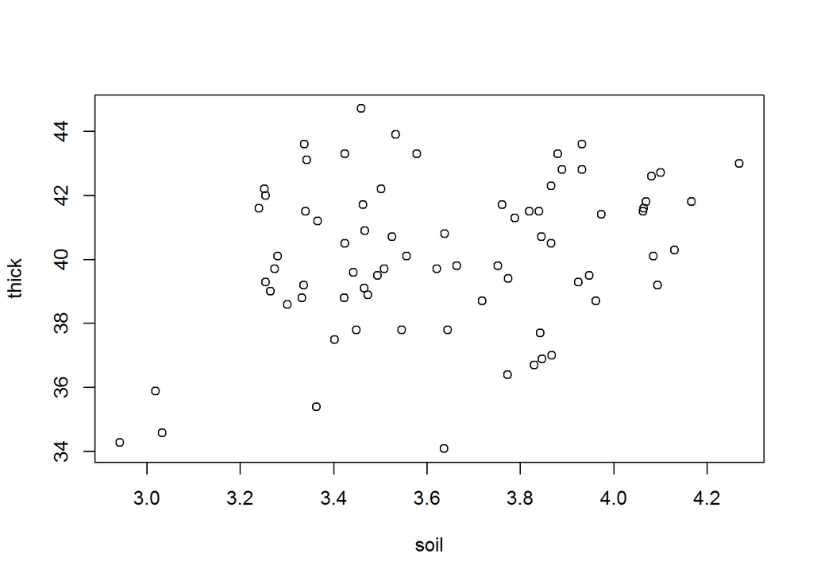

```r
plot(thick~soil, data=spdata)
```

We see that there can be a linear relationship between these two variables. Firstly, build the model with fixed effects.

```r
model0 <- lme(fixed = thick ~ soil, data = spdata, random = ~ 1 | dummy, method = "ML")
summary(model0)
```

```
## Linear mixed-effects model fit by maximum likelihood
##  Data: spdata
##        AIC      BIC    logLik
##   342.3182 351.5881 -167.1591
##
## Random effects:
##  Formula: ~1 | dummy
##          (Intercept) Residual
## StdDev: 4.815352e-05 2.247569
##
## Fixed effects: thick ~ soil
##                Value Std.Error DF   t-value p-value
## (Intercept) 31.94203 3.1569891 73 10.117878  0.0000
## soil         2.25521 0.8655887 73  2.605407  0.0111
##  Correlation:
##      (Intr)
## soil -0.997
##
## Standardized Within-Group Residuals:
##         Min          Q1         Med          Q3         Max
## -2.68798974 -0.53279498  0.03896491  0.66007203  2.20612991
##
## Number of Observations: 75
## Number of Groups: 1
```

We see that soil is important variable.

Now let’s build the second model, which takes into account spatial structure.

```r
model1 <- lme(fixed = thick ~ soil, data=spdata, correlation = corGaus(form = ~ east + north), random= ~1|dummy, method="ML")
summary(model1)
```

```
## Linear mixed-effects model fit by maximum likelihood
##  Data: spdata
##        AIC      BIC    logLik
##   91.50733 103.0948 -40.75366
##
## Random effects:
##  Formula: ~1 | dummy
##          (Intercept) Residual
## StdDev: 7.497427e-05 2.088388
##
## Correlation Structure: Gaussian spatial correlation
##  Formula: ~east + north | dummy
##  Parameter estimate(s):
##    range
## 20.43726
## Fixed effects: thick ~ soil
##                Value Std.Error DF  t-value p-value
## (Intercept) 40.32797 0.5877698 73 68.61184  0.0000
## soil         0.00348 0.0160363 73  0.21693  0.8289
##  Correlation:
##      (Intr)
## soil -0.102
##
## Standardized Within-Group Residuals:
##        Min         Q1        Med         Q3        Max
## -2.9882458 -0.7133759 -0.1146242  0.6745680  2.0877341
##
## Number of Observations: 75
## Number of Groups: 1
```

Here we see that p-value for soil variable is very high, so it is not important (i.e. information about soil is mostly included in spatial structure).

## Conclusions

Looking at measures of model fit (AIC, BIC, logLik) we see that the second model is better. Also in the first model soil is significant while in the second is not.